# Example Data Processing/Analysis from Joshua Hayes, PhD

### This file contains a sample of the data-prep and analysis that went into the my original concept for an interactive web-app: The "Housing Market Friendliness" Predictor

I created this app all the way from original concept through to deployment. You can access the app here: https://marketfriendliness.herokuapp.com/

Please note that the app is hosted on a free server, and thus loads slowly the first time it has a visitor while the dyno comes up.

I present this file as an example of my thought process, method, and coding ability. I hope you enjoy, and thank you for taking the time to read it.

Best Regards, Joshua D. Hayes, Ph.D.

## General Concept

I was inspired by the interactive visualizations that allow you to see past income differences across regions (example: https://project.wnyc.org/median-income-nation/#6/37.388/-119.773), so I endeavored to make a project that would allow a user to visually assess the **future** competitiveness of housing markets.

#### My goals were:

- To have a visual representation of the data mapped geographically
- Allow for comparisons to be made with user-specified inputs
- Make predictions about how housing markets would compare in the future

#### The major challenges to address are:

1. Finding a data source to assess housing market "competitiveness" or (inversely) "friendliness"
2. Preparing that data for this particular use-case
3. Loading that data into an interactive, geographic visualized format
4. Creating valid, defensible, and accurate predictions for future housing market values (a time-series problem)

The above challenges are not necessarily ordered sequentially insofar as how to build the project. I ordered them, here, instead by simplicity of task.

## Addressing those challenges:

### 1. Finding a data source

You can read about this data here: http://www.freddiemac.com/research/datasets/sf_loanlevel_dataset.html

The drawback of the Freddie Mac (FM) data is that the anonymizing of the home loans blurs the geographic location of each data point such that a home loan offered in Washington D.C. would originally be recorded under the zipcode (20001) but is anonymized into the truncated zipcode (200). However, many of the other data sets had large pockets of missing data, either by region or by time-period. The FM data is incredibly rich and robust, in large part due to its number of data points, so what it lacks in regional-specificity it makes up for in consistency, reliability, and quality for use in predictive analytics.

### 2. Cleaning Freddie Mac DF

#### So let's get started on processing this data!

```python
#First we'll need to load in a number of packages
import csv
import xml.etree.cElementTree as et
import pandas as pd
import numpy as np
from bokeh.plotting import figure, output_file, show
from bokeh.embed import components
import os
import feather
import pickle
from bokeh.io import show
from bokeh.models import LogColorMapper
from bokeh.palettes import Viridis6 as palette
from bokeh.plotting import figure
from matplotlib import pyplot
from pandas.tools.plotting import autocorrelation_plot
import seaborn as sns
import warnings
warnings.filterwarnings('ignore') #for presentation purposes only
```

Each file has a lot of extra information that we will not need. So we will want to drop that extra data out of every file before we merge all the data together. That will be a more efficient use of memory.

Since we have to go through each file, we might as well clean each file at the same time and make sure that they each file is uniform and ready to merge together. Additionally, the format of much of the data needs to be altered. Here are just a few examples:

- **I want to use "Credit Score" (FICO) to determine how competitive a housing market is based on the logic: as the average for borrowers' credit scores goes up, that region is likely a more competitive housing market.** We can figure out the average credit score of borrowers by aggregating across region and time. However, when any borrower's FICO score was missing the default value of '9999' was input. That won't do. So we're going to drop cases where the credit score is missing. Also, some credit scores seem to be input erroneously. Some credit scores show as being 150 or 170, but the range of credit scores doesn't go below 300. These oddly-low credit score inputs seem to be only in the American South (ex. Alabama, Mississippi) which leads me to think there is a story behind why these values are input... however, for this use-case, we are just going to drop these cases because they are uncommon.
- **I want to use the percentage of first time home buyers in a region as a measure of how competitive a region is based on the logic: first time home buyers are less competitive buyers, and so where there are fewer of these borrowers the housing market is likely more competitive.** Each loan has a "flag" to say whether that borrow is a "first time home buyer" or not. By aggregating across region and time, we can see what percentage of home loans that went to first time home buyers. But of course, it is not that simple right away. This "flag" has three categories: "yes","no", and "9." Dipping into the documentation reveals that "9" refers to a number of edge-cases, such as buying a vacation home instead of a primary residence. In some cases, the percentage of these edge-cases can be quite large and whether to include, drop, or recode these instances as either "first time" or "not first time" is an important discussion to have. I wanted to be as conservative as possible, so I kept these cases in the analysis and coded them as "not first time home buyers." I believe this will more strictly penalize housing markets that have few true first time home buyers.
- My geographic information is stores in zipcodes... but in truncated zipcodes, in order to maintain users' anonymity. Later these zipcodes will have to be merged with other datasets, so I want to turn them from this "845" to something like "84500".
- Some regions in the data set are not in the continental United States, or are difficult map (example Guam, Virgin Islands, and Washington DC). I just drop these regions out of my app.

```python
#Looping through each file to clean them for merging
for year_val in range(1999, 2017):
    filename = 'data/mortgage/sample_orig_' + str(year_val) + '.txt'
    dmort = pd.read_csv(filename, sep='|', delimiter=None, names=['fico','dt_first_pi','flag_fthb','loan_end_date','five','six','seven','eight','nine','ten','eleven','twelve','thirteen','fourteen','fifteen','sixteen','st','eighteen','zipcode','twenty','twentone','twentytwo','twentythree','twentyfour','twentyfive','twentysix','twentyseven'])
    dmort = dmort[['fico','dt_first_pi','flag_fthb','zipcode','st']]
    #FTHB recode
    dmort['flag_fthb'] = dmort['flag_fthb'].replace("9",0)
    dmort['flag_fthb'] = dmort['flag_fthb'].replace("Y", 1)
    dmort['flag_fthb'] = dmort['flag_fthb'].replace("N",0)
    dmort['flag_fthb'].astype(int)
    #Fix zipcodes to be a number-- it has some weird values throwing it off
    dmort['zipcode'] = dmort['zipcode'].fillna(0).astype(int)
    dmort['zipcode'] = dmort['zipcode'].astype(str)
    dmort = dmort[dmort['zipcode'] != '0']
    dmort['zipcode'] = [x.rjust(5, '0') for x in dmort['zipcode']]
    dmort['zipcode'] = [str(x)[:-2] for x in dmort.zipcode]
    #Creating datetime
    dmort['loanDate'] = pd.to_datetime(dmort['dt_first_pi'], format= '%Y%m')
    #Cleaning state
    dmort = dmort[dmort['st'] != 'PR']
    dmort = dmort[dmort['st'] != 'DC']
    dmort = dmort[dmort['st'] != 'VI']
    dmort = dmort[dmort['st'] != 'GU']
    dmort = dmort[dmort['st'] != 'MP']
    dmort = dmort[dmort['st'] != 'AS']
    #Cleaning fico
    dmort = dmort[dmort['fico'] != 9999]
    dmort = dmort[dmort['fico'] > 300]
    dmort = dmort.drop(columns='dt_first_pi')
    savefile = 'data/mortgage/dm' + str(year_val) + '.csv'
    dmort.to_csv(savefile, index=False)
```

Now that they're clean. Let's merge them all together.

```python
#Combining all the data files
df = pd.read_csv('data/mortgage/dm1999.csv')
for year_val in range(2000, 2017):
    add_file = 'data/mortgage/dm' + str(year_val) + '.csv'
    df2 = pd.read_csv(add_file)
    df = df.append(df2, ignore_index=True)
    print(df.shape)           #Here I just want to see how large my combined-data gets with each iteration.
df.to_csv('data/mortgage/mort_all_years.csv')
```

```
(98508, 5)
(147967, 5)
(197604, 5)
(247378, 5)
(297120, 5)
(346743, 5)
(396430, 5)
(446076, 5)
(495778, 5)
(545583, 5)
(595404, 5)
(645236, 5)
(695065, 5)
(744871, 5)
(794690, 5)
(844526, 5)
(894358, 5)
```

```python
df.head(5)
```

|  | fico | flag_fthb | zipcode | st | loanDate |
| --- | --- | --- | --- | --- | --- |
| 0 | 799 | 0 | 261 | WV | 1999-03-01 |
| 1 | 635 | 0 | 447 | OH | 2002-12-01 |
| 2 | 787 | 0 | 305 | GA | 1999-05-01 |
| 3 | 726 | 0 | 660 | KS | 1999-04-01 |
| 4 | 748 | 0 | 452 | OH | 1999-05-01 |

The data is looking pretty good. Let's go ahead and save this as our cleaned, finalized dataset for the Freddie Mac data:

```python
df = pd.read_csv('data/mortgage/mort_all_years.csv')
```

#### Now let's calculate the aggregated values that we will use to measure housing market competitiveness

1. Average Borrow Credit Score: 'fico'
2. Percentage of First Time Home Buyers in a Region: 'flag_fthb'

These values won't be the final values that populate into our visualization, but they will give us the values associated with each county so that we can test if they work in the visualization.

```python
#getting average values
df_FM = df.groupby(['zipcode'])['fico', 'flag_fthb'].mean()
df_FM['zipcode'] = df_FM.index
df_FM['zipcode'] = [str(x).rjust(3, '0') for x in df_FM['zipcode']]
df_FM['fico'] = [int(x) for x in df_FM['fico']]
df_FM['flag_fthb']= [round(x*100, 2) for x in df_FM['flag_fthb']]
df_FM.head(5)
```

| zipcode | fico | flag_fthb | zipcode |
| --- | --- | --- | --- |
| 10 | 740 | 11.94 | 010 |
| 11 | 724 | 14.29 | 011 |
| 12 | 749 | 6.90 | 012 |
| 13 | 740 | 13.57 | 013 |
| 14 | 733 | 12.25 | 014 |

I'm going to need a list of states in order to visualize each state later. So let's get that list now.

```python
state_list = df['st'].unique()
state_list
```

```
array(['WV', 'OH', 'GA', 'KS', 'CA', 'UT', 'MD', 'MI', 'PA', 'FL', 'AZ',
       'NY', 'MA', 'NJ', 'MN', 'WI', 'CT', 'WA', 'SC', 'TX', 'MT', 'CO',
       'TN', 'IA', 'NM', 'IN', 'ME', 'VA', 'MO', 'NC', 'OR', 'NV', 'IL',
       'AK', 'KY', 'MS', 'ND', 'NE', 'LA', 'NH', 'AL', 'RI', 'ID', 'OK',
       'SD', 'AR', 'HI', 'VT', 'WY', 'DE'], dtype=object)
```

## 3. Finding a Visualization Strategy

I looked at a number of different formats for visualization (probably 5-6 options). I wanted to be able to quickly and easily compare across regions. Overlaying onto google maps doesn't work that well, because overlaying works much better with plotted points than it does with mapping regions. Ultimately, I liked this model: https://bokeh.pydata.org/en/latest/docs/gallery/texas.html

I appreciate the interactivity of Bokeh plots (zooming and scrolling), and I really dig the mouse-over tool-tip. I want to load a lot of information into a tool-tip like that. **The key to this graph is that they've already done the work of drawing out hte boundaries of county-lines. That is one of the most vexing parts of this entire project.** By using their template to graph the county lines, I don't need to code my own. That will save a **lot** of work.

The trade-off of course is that I'll be limited to their format. But I quite like what they've got here so I feel fine proceeding. I will need to look at how the Bokeh team has loaded their data into this visualization and then I'm going to conform my own data into that same format. Then I just need to point this graph from their data to my own instead and my data should flow through into the visualization.

#### Counties webscraping dataset

So first thing is first, I need to get the US_Counties data that this visualization uses to draw county lines.

```python
#This is a chunk of code from the Bokeh team that reads in the counties data
def _read_data():
    '''
    '''
    nan = float('NaN')
    data = {}
    with open('data/US_Counties.csv', encoding='utf-8') as f:
        next(f)
        reader = csv.reader(f, delimiter=str(','), quotechar=str('"'))
        for row in reader:
            name, dummy, state, dummy, geometry, dummy, dummy, dummy, det_name, state_id, county_id, dummy, dummy = row
            xml = et.fromstring(geometry)
            lats = []
            lons = []
            for i, poly in enumerate(xml.findall('.//outerBoundaryIs/LinearRing/coordinates')):
                if i > 0:
                    lats.append(nan)
                    lons.append(nan)
                coords = (c.split(',')[:2] for c in poly.text.split())
                lat, lon = list(zip(*[(float(lat), float(lon)) for lon, lat in
                    coords]))
                lats.extend(lat)
                lons.extend(lon)
            data[(int(state_id), int(county_id))] = {
                'name' : name,
                'detailed name' : det_name,
                'state' : state,
                'lats' : lats,
                'lons' : lons,
            }
    return data
```

```python
#This is code from the Bokeh team that reads in that data, and then puts it into a number of lists
counties = _read_data()
counties = {
    code: county for code, county in counties.items()}

county_xs = [county["lons"] for county in counties.values()]
county_ys = [county["lats"] for county in counties.values()]
county_names = [county['name'] for county in counties.values()]
county_states = [county['state'] for county in counties.values()]
#And then they put those lists into a dictionary.
#The graph then calls on this dictionary to draw the plot
data=dict(
    x=county_xs,
    y=county_ys,
    name=county_names,
    state=county_states
)
```

I need to make sure that the available 'states' in this dataset matches those states in the Freddie Mac dataset. Otherwise a user might try to visualize Guam, or Washington D.C. and the app will error out.

```python
state_list = list(set(data['state']))
state_list = [x.upper() for x in state_list]
state_list.sort()
state_list
#need to remove AS, GU, MP, PR, DC, VI
bad_state_list = ['AS','DC','GU','MP','PR','VI']
for item in bad_state_list:
    state_list.remove(item)
len(state_list)
```

```
50
```

### 4. Modeling Change in County Values: A Time-Series Problem

Looking at the values for Average FICO Score and Percentage of First Time Home Buyers over time for just one county, we can see the incredible amount of variation.

[figure not shown]

Attempting to plot a linear regression on this data is, well, comically bad.

[figure not shown]

For FTHB% we might as well just take the average of a county over the past 20 years and assume that is the future value. That is not a good way to make predictions! We will need to find a better solution. A clutch insight here is that we are not trying to establish a single pattern for the entire history of distributed points. We really want to take the past few data points in the time series, and use those to inform our future predictions.

### An ARIMA Model Solution

Spoiler Alert: Using Auto-Regressive Integrated Moving Average models, we can create a model with results like this:

(blue = actual values, red = model's predicted values)

[figure not shown]

The rest of this notebook will go over creating these results.

**The general process is as follows:**

- Limit the dataset to a single zipcode
- Create an ARIMA model for that zipcode
- Run a number of evaluations to determine the most effective hyperparameters of the ARIMA model for that county
- Repeat this process for a few counties, to determine which hyperparameters tend to work well across all counties
- Loop through each zipcode and make a zipcode-specific ARIMA model using the ideal model hyperparameters
- Predict future values for that zipcode
- Store each zipcode's predicted values in a dictionary

```python
from statsmodels.tsa.arima_model import ARIMA
from sklearn.metrics import mean_squared_error
```

```python
#getting average values
df_pred = df.groupby(['zipcode', 'loanDate'])['fico', 'flag_fthb'].mean()
df_pred.head(5)
# df_pred = df_pred.drop(columns = 'zipcode')
# df_pred['zipcode'] = df_pred.index
df_pred = df_pred.reset_index()
df_pred['zipcode'] = [str(x).rjust(3, '0') for x in df_pred['zipcode']]
df_pred['loanDate'] = pd.to_datetime(df_pred['loanDate'], format= '%Y-%m-%d')
# df_pred1 = df_pred1.reset_index(level='zipcode')
df_pred['fico'] = [int(x) for x in df_pred['fico']]
print(df_pred.shape)
print(df_pred.tail(5))
zipcode_list = df_pred.zipcode.unique()
```

```
(147137, 4)
       zipcode   loanDate  fico  flag_fthb
147132     999 2015-05-01   766        0.0
147133     999 2016-05-01   753        0.0
147134     999 2016-06-01   806        0.0
147135     999 2016-08-01   793        0.0
147136     999 2016-11-01   777        0.0
```

```python
df_pred.head(5)
```

|  | zipcode | loanDate | fico | flag_fthb |
| --- | --- | --- | --- | --- |
| 0 | 010 | 1999-03-01 | 697 | 0.166667 |
| 1 | 010 | 1999-04-01 | 707 | 0.142857 |
| 2 | 010 | 1999-05-01 | 721 | 0.000000 |
| 3 | 010 | 1999-06-01 | 703 | 0.000000 |
| 4 | 010 | 1999-07-01 | 728 | 0.000000 |

```python
zipcode_fico_preds = dict()
zipcode_fthb_preds = dict()
zipsorted_df = df_pred.sort_values(by=['zipcode'])
zipcount = 0

for zippie in zipcode_list:
    df_test_pred = zipsorted_df[zipsorted_df['zipcode'] == str(zippie)]
    df_test_pred = df_test_pred.drop(columns = ['zipcode', 'flag_fthb'])
    df_test_pred = df_test_pred.set_index('loanDate')
    #now I have the fico df ready to go
    # fit model
    try:
        model = ARIMA(df_test_pred, order=(2,0,2))
        model_fit = model.fit(disp=0)
        #make prediction
        prediction = model_fit.forecast(steps=6)[0].mean()
        #store fico prediction
        zipcode_fico_preds[zippie] = prediction
    except:
        pass
    zipcount += 1
    if zipcount % 50 == 0:
        print('%s zips down' % str(zippie))
```

```
060 zips down
120 zips down
170 zips down
227 zips down
278 zips down
329 zips down
386 zips down
440 zips down
491 zips down
548 zips down
605 zips down
661 zips down
722 zips down
778 zips down
832 zips down
904 zips down
958 zips down
```

```python
zip_fico_preds = []
for key, value in zipcode_fico_preds.items():
    temp = [key,value]
    zip_fico_preds.append(temp)
zip_fico_preds[:5]
```

```
[['010', 714.6909286461961],
 ['013', 737.7729069419771],
 ['016', 715.7345756266654],
 ['017', 742.6122953591871],
 ['018', 707.5623542449035]]
```

```python
zipcount = 0

for zippie in zipcode_list:
    df_test_pred = zipsorted_df[zipsorted_df['zipcode'] == str(zippie)]
    df_test_pred = df_test_pred.drop(columns = ['zipcode', 'fico'])
    df_test_pred = df_test_pred.set_index('loanDate')
    #now I have the fico df ready to go
    # fit model
    try:
        model = ARIMA(df_test_pred, order=(2,0,2))
        model_fit = model.fit(disp=0)
        #make prediction
        prediction = model_fit.forecast(steps=6)[0].mean()
        #store fico prediction
        zipcode_fthb_preds[zippie] = prediction
    except:
        pass
    zipcount += 1
    if zipcount % 50 == 0:
        print('%s zips down' % str(zippie))
```

```
060 zips down
120 zips down
170 zips down
227 zips down
278 zips down
329 zips down
386 zips down
440 zips down
491 zips down
548 zips down
605 zips down
661 zips down
722 zips down
778 zips down
832 zips down
904 zips down
958 zips down
```

```python
zip_fthb_preds = []
for key, value in zipcode_fthb_preds.items():
    temp = [key,value]
    zip_fthb_preds.append(temp)
zip_fthb_preds[:5]
```

```
[['010', 0.13882097278147842],
 ['015', 0.11420874525215978],
 ['016', 0.15968778378549633],
 ['017', 0.10968497847566265],
 ['018', 0.08509418228086123]]
```

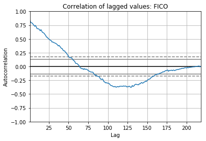

```python
autocorrelation_plot(df_test_pred)
pyplot.title('Correlation of lagged values: FICO')
# pyplot.savefig('visualizations/timecorrelation_over_time_alameda.png')
pyplot.show()
```

```
                             ARIMA Model Results
==============================================================================
Dep. Variable:                 D.fico   No. Observations:                  217
Model:                 ARIMA(2, 1, 0)   Log Likelihood                -833.934
Method:                       css-mle   S.D. of innovations             11.283
Date:                Wed, 14 Nov 2018   AIC                           1675.868
Time:                        20:46:31   BIC                           1689.388
Sample:                    03-01-1999   HQIC                          1681.330
                         - 03-01-2017
================================================================================
                   coef    std err          z      P>|z|      [0.025      0.975]
--------------------------------------------------------------------------------
const           -0.0666      0.435     -0.153      0.879      -0.919       0.786
ar.L1.D.fico    -0.4627      0.071     -6.559      0.000      -0.601      -0.324
ar.L2.D.fico    -0.3045      0.070     -4.330      0.000      -0.442      -0.167
                                    Roots
=============================================================================
                  Real          Imaginary           Modulus         Frequency
-----------------------------------------------------------------------------
AR.1           -0.7597           -1.6451j            1.8121           -0.3189
AR.2           -0.7597           +1.6451j            1.8121            0.3189
-----------------------------------------------------------------------------
```

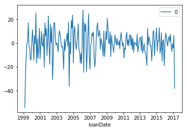

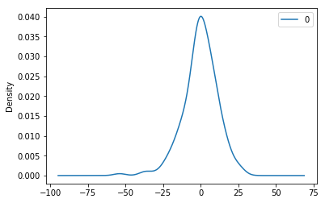

```
                0
count  217.000000
mean    -0.172174
std     11.442325
min    -53.933443
25%     -5.470434
50%      0.132196
75%      6.600988
max     27.950662
```

```python
# fit model
model = ARIMA(df_test_pred, order=(2,1,0))
model_fit = model.fit(disp=0)
print(model_fit.summary())
# plot residual errors
residuals = pd.DataFrame(model_fit.resid)
residuals.plot()
pyplot.savefig('visualizations/residuals_alameda.png')
pyplot.show()
residuals.plot(kind='kde')
pyplot.savefig('visualizations/residuals_kdensity_alameda.png')
pyplot.show()
print(residuals.describe())
```

#### Here I use MSE of my predicted values from the observed values to see how well my model fits the data.

I use code that essentially replicates GridSearchCV from scikit-learn to compare the errors across different sets of hyper-parameters.

```python
from sklearn.metrics import mean_squared_error
import warnings

# evaluate an ARIMA model for a given order (p,d,q)
def evaluate_arima_model(X, arima_order):
	# prepare training dataset
	train_size = int(len(X) * 0.66)
	train, test = X[0:train_size], X[train_size:]
	history = [x for x in train]
	# make predictions
	predictions = list()
	for t in range(len(test)):
		model = ARIMA(history, order=arima_order)
		model_fit = model.fit(disp=0)
		yhat = model_fit.forecast()[0]
		predictions.append(yhat)
		history.append(test[t])
	# calculate out of sample error
	error = mean_squared_error(test, predictions)
	return error

# evaluate combinations of p, d and q values for an ARIMA model
def evaluate_models(dataset, p_values, d_values, q_values):
	dataset = dataset.astype('float32')
	best_score, best_cfg = float("inf"), None
	for p in p_values:
		for d in d_values:
			for q in q_values:
				order = (p,d,q)
				try:
					mse = evaluate_arima_model(dataset, order)
					if mse < best_score:
						best_score, best_cfg = mse, order
					print('ARIMA%s MSE=%.3f' % (order,mse))
				except:
					continue
	print('Best ARIMA%s MSE=%.3f' % (best_cfg, best_score))

# evaluate parameters
p_values = [1, 2, 5,]
d_values = range(0, 3)
q_values = range(0, 3)
warnings.filterwarnings("ignore")
evaluate_models(df_test_pred.values, p_values, d_values, q_values)
```

[output not shown]

```python
X = df_test_pred.values
size = int(len(X) * 0.66)
train, test = X[0:size], X[size:len(X)]
history = [x for x in train]
predictions = list()
for t in range(len(test)):
	model = ARIMA(history, order=(2,1,0))
	model_fit = model.fit(disp=0)
	output = model_fit.forecast()
	yhat = output[0]
	predictions.append(yhat)
	obs = test[t]
	history.append(obs)
	print('predicted=%f, expected=%f' % (yhat, obs))
error = mean_squared_error(test, predictions)
print('Test MSE: %.3f' % error)
```

```
predicted=775.877583, expected=776.000000
predicted=775.917744, expected=763.000000
predicted=768.137943, expected=764.000000
predicted=767.662152, expected=762.000000
predicted=762.773888, expected=768.000000
predicted=766.163824, expected=775.000000
predicted=770.435769, expected=768.000000
predicted=769.278380, expected=772.000000
predicted=772.588817, expected=770.000000
predicted=769.970905, expected=776.000000
predicted=774.245738, expected=781.000000
predicted=777.385426, expected=775.000000
predicted=776.506502, expected=782.000000
predicted=781.044246, expected=775.000000
predicted=776.383053, expected=780.000000
predicted=780.184658, expected=772.000000
predicted=774.410286, expected=775.000000
predicted=776.296670, expected=776.000000
predicted=774.988983, expected=774.000000
predicted=774.899385, expected=772.000000
predicted=773.752654, expected=781.000000
predicted=777.895946, expected=770.000000
predicted=772.589370, expected=769.000000
predicted=772.925399, expected=775.000000
predicted=772.876356, expected=777.000000
predicted=774.638499, expected=779.000000
predicted=777.842820, expected=771.000000
predicted=774.270787, expected=780.000000
predicted=778.622234, expected=770.000000
predicted=772.153467, expected=767.000000
predicted=771.510953, expected=771.000000
predicted=770.310703, expected=763.000000
predicted=765.624404, expected=758.000000
predicted=762.721488, expected=751.000000
predicted=755.614796, expected=737.000000
predicted=745.033809, expected=758.000000
predicted=752.705024, expected=751.000000
predicted=748.138108, expected=753.000000
predicted=754.145803, expected=757.000000
predicted=754.719556, expected=752.000000
```

[output cut: 21 more lines]

```
predicted=744.508610, expected=753.000000
predicted=745.167087, expected=751.000000
predicted=747.918094, expected=749.000000
predicted=750.558972, expected=748.000000
predicted=749.090457, expected=752.000000
predicted=750.521382, expected=756.000000
predicted=753.007344, expected=754.000000
predicted=753.738528, expected=761.000000
predicted=758.532782, expected=756.000000
predicted=756.208196, expected=749.000000
predicted=753.777570, expected=753.000000
predicted=753.394735, expected=749.000000
predicted=749.613817, expected=756.000000
predicted=754.102661, expected=716.000000
Test MSE: 70.506
```

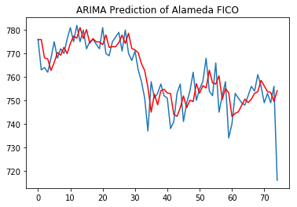

```python
# plot
pyplot.plot(test)
pyplot.plot(predictions, color='red')
pyplot.title('ARIMA Prediction of Alameda FICO')

pyplot.savefig('visualizations/arimapreds_over_time_alameda.png')
pyplot.show()
```

```python
df_test_time = df_pred
# df_test_time = df_test_pred.index.to_julian_date()
df_test_time['Date'] = df_pred['loanDate'].map(pd.datetime.toordinal)
df_test_time = df_test_time[df_test_time['zipcode'] == '945']
df_test_time = df_test_time.drop(columns=['loanDate', 'zipcode','flag_fthb'])
df_test_time.sort_values(by=['Date'])
df_test_time.head(5)
```

|  | fico | Date |
| --- | --- | --- |
| 137861 | 771 | 729786 |
| 137862 | 717 | 729814 |
| 137863 | 711 | 729845 |
| 137864 | 719 | 729875 |
| 137865 | 717 | 729906 |

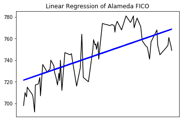

```python
from sklearn import linear_model
from sklearn.model_selection import train_test_split


X_train, X_test, y_train, y_test = train_test_split(df_test_time['Date'], df_test_time['fico'], test_size=0.33)


# Create linear regression object
regr = linear_model.LinearRegression()

# Train the model using the training sets
regr.fit(np.array(X_train).reshape(-1, 1), y_train)

# Make predictions using the testing set
y_pred = regr.predict(np.array(X_test).reshape(-1, 1))

# Plot outputs
xs, ys = zip(*sorted(zip(X_test, y_test)))
pyplot.plot(xs, ys,  color='black')
pyplot.plot(X_test, y_pred, color='blue', linewidth=2)

pyplot.xticks(())
# pyplot.yticks(())
pyplot.title('Linear Regression of Alameda FICO')

# pyplot.savefig('visualizations/linearpred_over_time_alameda.png')
pyplot.show()
```

### Now I replicate the same process done on FICO score above, for FTHB Percentage below

```python
df_test_pred2 = df_pred[df_pred['zipcode'] == '945']
# print(df_test_pred.head(5))
df_test_pred2 = df_test_pred2.drop(columns = ['zipcode', 'fico'])
df_test_pred2 = df_test_pred2.set_index('loanDate')
df_test_pred2.tail(5)
```

| loanDate | flag_fthb |
| --- | --- |
| 2016-11-01 | 0.109589 |
| 2016-12-01 | 0.101449 |
| 2017-01-01 | 0.150943 |
| 2017-02-01 | 0.047619 |
| 2017-03-01 | 0.000000 |

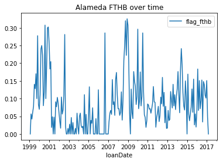

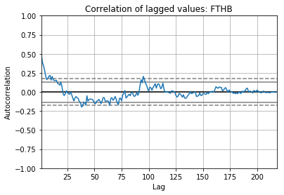

```python
df_test_pred2.plot()
pyplot.title('Alameda FTHB over time')
pyplot.savefig('visualizations/fthb_over_time_alameda.png')
pyplot.show()
autocorrelation_plot(df_test_pred2)
pyplot.title('Correlation of lagged values: FTHB')
pyplot.savefig('visualizations/timecorrelation_fthb_alameda.png')
pyplot.show()
```

```
                             ARIMA Model Results
==============================================================================
Dep. Variable:            D.flag_fthb   No. Observations:                  217
Model:                 ARIMA(2, 1, 2)   Log Likelihood                 281.509
Method:                       css-mle   S.D. of innovations              0.066
Date:                Wed, 14 Nov 2018   AIC                           -551.018
Time:                        21:07:32   BIC                           -530.739
Sample:                    03-01-1999   HQIC                          -542.826
                         - 03-01-2017
=====================================================================================
                        coef    std err          z      P>|z|      [0.025      0.975]
-------------------------------------------------------------------------------------
const             -8.228e-06      0.001     -0.009      0.993      -0.002       0.002
ar.L1.D.flag_fthb    -0.7087      0.099     -7.184      0.000      -0.902      -0.515
ar.L2.D.flag_fthb     0.2333      0.099      2.358      0.019       0.039       0.427
ma.L1.D.flag_fthb     0.1528      0.065      2.346      0.020       0.025       0.280
ma.L2.D.flag_fthb    -0.8472      0.065    -13.076      0.000      -0.974      -0.720
                                    Roots
=============================================================================
                  Real          Imaginary           Modulus         Frequency
-----------------------------------------------------------------------------
AR.1           -1.0489           +0.0000j            1.0489            0.5000
AR.2            4.0872           +0.0000j            4.0872            0.0000
MA.1           -1.0000           +0.0000j            1.0000            0.5000
MA.2            1.1803           +0.0000j            1.1803            0.0000
-----------------------------------------------------------------------------
```

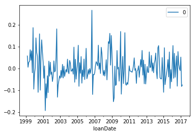

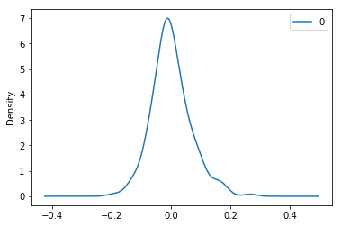

```
                0
count  217.000000
mean     0.001131
std      0.066245
min     -0.193718
25%     -0.038676
50%     -0.006000
75%      0.036188
max      0.266057
```

```python
# fit model
model = ARIMA(df_test_pred2, order=(2,1,2))
model_fit = model.fit(disp=0)
print(model_fit.summary())
# plot residual errors
residuals = pd.DataFrame(model_fit.resid)
residuals.plot()
pyplot.savefig('visualizations/residuals_fthb_alameda.png')
pyplot.show()
residuals.plot(kind='kde')
pyplot.savefig('visualizations/residuals_fthb_kdensity_alameda.png')
pyplot.show()
print(residuals.describe())
```

```python
from sklearn.metrics import mean_squared_error
import warnings

# evaluate an ARIMA model for a given order (p,d,q)
def evaluate_arima_model(X, arima_order):
	# prepare training dataset
	train_size = int(len(X) * 0.66)
	train, test = X[0:train_size], X[train_size:]
	history = [x for x in train]
	# make predictions
	predictions = list()
	for t in range(len(test)):
		model = ARIMA(history, order=arima_order)
		model_fit = model.fit(disp=0)
		yhat = model_fit.forecast()[0]
		predictions.append(yhat)
		history.append(test[t])
	# calculate out of sample error
	error = mean_squared_error(test, predictions)
	return error

# evaluate combinations of p, d and q values for an ARIMA model
def evaluate_models(dataset, p_values, d_values, q_values):
	dataset = dataset.astype('float32')
	best_score, best_cfg = float("inf"), None
	for p in p_values:
		for d in d_values:
			for q in q_values:
				order = (p,d,q)
				try:
					mse = evaluate_arima_model(dataset, order)
					if mse < best_score:
						best_score, best_cfg = mse, order
					print('ARIMA%s MSE=%.3f' % (order,mse))
				except:
					continue
	print('Best ARIMA%s MSE=%.3f' % (best_cfg, best_score))

# evaluate parameters
p_values = [1, 2, 3]
d_values = range(0, 3)
q_values = range(0, 3)
warnings.filterwarnings("ignore")
evaluate_models(df_test_pred2.values, p_values, d_values, q_values)
```

```
ARIMA(1, 0, 0) MSE=0.003
ARIMA(1, 0, 1) MSE=0.002
ARIMA(1, 1, 0) MSE=0.003
ARIMA(1, 1, 1) MSE=0.003
ARIMA(1, 1, 2) MSE=0.003
ARIMA(1, 2, 0) MSE=0.006
ARIMA(2, 0, 0) MSE=0.003
ARIMA(2, 0, 1) MSE=0.003
ARIMA(2, 0, 2) MSE=0.002
ARIMA(2, 1, 0) MSE=0.003
ARIMA(2, 1, 1) MSE=0.003
ARIMA(2, 1, 2) MSE=0.003
ARIMA(2, 2, 0) MSE=0.005
ARIMA(3, 0, 0) MSE=0.003
ARIMA(3, 0, 2) MSE=0.002
ARIMA(3, 1, 0) MSE=0.003
ARIMA(3, 2, 0) MSE=0.005
Best ARIMA(2, 0, 2) MSE=0.002
```

```python
X = df_test_pred2.values
size = int(len(X) * 0.66)
train, test = X[0:size], X[size:len(X)]
history = [x for x in train]
predictions = list()
for t in range(len(test)):
	model = ARIMA(history, order=(2,1,0))
	model_fit = model.fit(disp=0)
	output = model_fit.forecast()
	yhat = output[0]
	predictions.append(yhat)
	obs = test[t]
	history.append(obs)
	print('predicted=%f, expected=%f' % (yhat, obs))
error = mean_squared_error(test, predictions)
print('Test MSE: %.3f' % error)
```

```
predicted=0.036361, expected=0.084746
predicted=0.058548, expected=0.081967
predicted=0.071760, expected=0.070423
predicted=0.077125, expected=0.071429
predicted=0.074556, expected=0.058824
predicted=0.064890, expected=0.071429
predicted=0.069402, expected=0.086957
predicted=0.077184, expected=0.134146
predicted=0.109445, expected=0.090909
predicted=0.099630, expected=0.089552
predicted=0.102209, expected=0.019231
predicted=0.052239, expected=0.046875
predicted=0.052316, expected=0.059701
predicted=0.047085, expected=0.078125
predicted=0.066938, expected=0.035088
predicted=0.050506, expected=0.051948
predicted=0.055467, expected=0.104167
predicted=0.076471, expected=0.085106
predicted=0.081180, expected=0.160000
predicted=0.131590, expected=0.078431
predicted=0.098153, expected=0.117647
predicted=0.120934, expected=0.031746
predicted=0.062526, expected=0.078125
predicted=0.078049, expected=0.015873
predicted=0.033971, expected=0.016667
predicted=0.031321, expected=0.066667
predicted=0.043347, expected=0.037975
predicted=0.039452, expected=0.041096
predicted=0.046841, expected=0.120000
predicted=0.082928, expected=0.096154
predicted=0.088706, expected=0.073529
predicted=0.090620, expected=0.140351
predicted=0.115544, expected=0.079365
predicted=0.092276, expected=0.111111
predicted=0.112026, expected=0.068966
predicted=0.081701, expected=0.105263
predicted=0.099107, expected=0.127660
predicted=0.109050, expected=0.176471
predicted=0.149357, expected=0.111111
predicted=0.131142, expected=0.060000
```

[output cut: 21 more lines]

```
predicted=0.053663, expected=0.183673
predicted=0.117184, expected=0.066667
predicted=0.093529, expected=0.150943
predicted=0.140628, expected=0.071429
predicted=0.089910, expected=0.093750
predicted=0.103154, expected=0.152542
predicted=0.119127, expected=0.033898
predicted=0.077914, expected=0.148148
predicted=0.121945, expected=0.139535
predicted=0.115613, expected=0.109589
predicted=0.127553, expected=0.101449
predicted=0.113843, expected=0.150943
predicted=0.129251, expected=0.047619
predicted=0.087274, expected=0.000000
Test MSE: 0.003
```

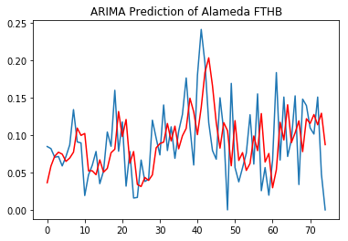

```python
# plot
pyplot.plot(test)
pyplot.plot(predictions, color='red')
pyplot.title('ARIMA Prediction of Alameda FTHB')

pyplot.savefig('visualizations/arimapreds_fthb_alameda.png')
pyplot.show()
```

```python
model_fit.forecast(steps=6)[0]
```

[output not shown]

```python
#taking the average of the next 6-months' of predictions
model_fit.forecast(steps=6)[0].mean()
```

```
0.08721914245170868
```

```python
df_test_time = df_pred
# df_test_time = df_test_pred.index.to_julian_date()
df_test_time['Date'] = df_pred['loanDate'].map(pd.datetime.toordinal)
df_test_time = df_test_time[df_test_time['zipcode'] == '945']
df_test_time = df_test_time.drop(columns=['loanDate', 'zipcode','fico'])
df_test_time.sort_values(by=['Date'])
df_test_time.head(5)
```

|  | flag_fthb | Date |
| --- | --- | --- |
| 137861 | 0.000000 | 729786 |
| 137862 | 0.056604 | 729814 |
| 137863 | 0.042254 | 729845 |
| 137864 | 0.061538 | 729875 |
| 137865 | 0.077922 | 729906 |

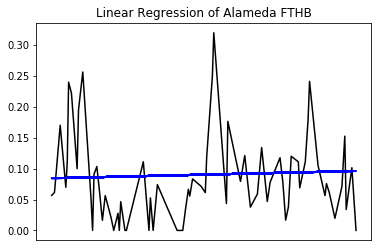

```python
from sklearn import linear_model
from sklearn.model_selection import train_test_split


X_train, X_test, y_train, y_test = train_test_split(df_test_time['Date'], df_test_time['flag_fthb'], test_size=0.33)


# Create linear regression object
regr = linear_model.LinearRegression()

# Train the model using the training sets
regr.fit(np.array(X_train).reshape(-1, 1), y_train)

# Make predictions using the testing set
y_pred = regr.predict(np.array(X_test).reshape(-1, 1))

# Plot outputs
xs, ys = zip(*sorted(zip(X_test, y_test)))
pyplot.plot(xs, ys,  color='black')
pyplot.plot(X_test, y_pred, color='blue', linewidth=2)

pyplot.xticks(())
# pyplot.yticks(())
pyplot.title('Linear Regression of Alameda FTHB')

pyplot.savefig('visualizations/linearpred_fthb_alameda.png')
pyplot.show()
```

Of course that is easier said than done. The biggest challenge is that my data is all by zipcode... but Bokeh draws county lines.

So we will need to "Cross-walk" our data from zipcodes over to counties. Luckily a dataframe exists out there has zipcodes and counties. Using this dataset I can do the following link:

**Freddie-Mac Data (zipcodes only) ---> Crosswalk Data (zipcodes and counties) ---> County-Lines Drawing Data (county only)**

### Merging FM Dataset with Cross-Walk Dataset

```python
#Working with the crosswalk set
walkies = pd.read_csv('data/zip_county_crosswalk.csv', sep=',')
print(walkies.head(5))
walkies = walkies[walkies.columns[0:4]]
walkies['zipcode'] = [str(x)[:-2] for x in walkies['ZIP']]
walkies['county'] = [' '.join(x.split(' ')[:-1]) for x in walkies['COUNTYNAME']]
walkies = walkies[walkies.columns[2:]]
#walkies = walkies.loc[walkies['STATE'] == 'TX']
walkies = walkies.drop_duplicates()
```

```
     ZIP      COUNTYNAME STATE  STCOUNTYFP CLASSFP
0  36003  Autauga County    AL        1001      H1
1  36006  Autauga County    AL        1001      H1
2  36067  Autauga County    AL        1001      H1
3  36066  Autauga County    AL        1001      H1
4  36703  Autauga County    AL        1001      H1
```

```python
walkies.head(5)
```

|  | STATE | STCOUNTYFP | zipcode | county |
| --- | --- | --- | --- | --- |
| 0 | AL | 1001 | 360 | Autauga |
| 4 | AL | 1001 | 367 | Autauga |
| 13 | AL | 1003 | 365 | Baldwin |
| 38 | AL | 1003 | 364 | Baldwin |
| 41 | AL | 1005 | 360 | Barbour |

```python
#merging that combined list with freddiemac
df_merged = pd.merge(df_FM, walkies, how='left', on=['zipcode'])
```

```python
#reducing values in counties
df_All = df_merged.groupby(['county','STATE'])['fico', 'flag_fthb'].mean()
#moving county names to column
df_All = df_All.reset_index()
```

```python
df_All.head(5)
```

|  | county | STATE | fico | flag_fthb |
| --- | --- | --- | --- | --- |
| 0 | Abbeville | SC | 733.50 | 10.0200 |
| 1 | Acadia | LA | 728.00 | 10.5700 |
| 2 | Accomack | VA | 736.00 | 6.8700 |
| 3 | Ada | ID | 738.50 | 8.1500 |
| 4 | Adair | IA | 738.75 | 13.1875 |

### Now that we have our values loaded into counties, instead of zipcodes, we need to change the format of the data to go into the graph. Instead of a dataframe, we need lists.

```python
list_All = [list(x) for x in df_All.values]
```

```python
list_All[1]
```

```
['Acadia', 'LA', 728.0, 10.57]
```

```python
list_All = [[x[0],x[1],x[2],x[3]] for x in list_All if x]
list_All = sorted(list_All)
list_All[:5]
```

```
[['Abbeville', 'SC', 733.5, 10.02],
 ['Acadia', 'LA', 728.0, 10.57],
 ['Accomack', 'VA', 736.0, 6.87],
 ['Ada', 'ID', 738.5, 8.15],
 ['Adair', 'IA', 738.75, 13.1875]]
```

```python
list_All[:5]
```

```
[['Abbeville', 'SC', 733.5, 10.02],
 ['Acadia', 'LA', 728.0, 10.57],
 ['Accomack', 'VA', 736.0, 6.87],
 ['Ada', 'ID', 738.5, 8.15],
 ['Adair', 'IA', 738.75, 13.1875]]
```

```python
county_fthb = [round(x[3],2) for x in list_All]
county_fico = [int(float(x[2])) for x in list_All]
```

```python
county_fico[:5]
```

```
[733, 728, 736, 738, 738]
```

```python
county_fthb[:5]
```

```
[10.02, 10.57, 6.87, 8.15, 13.19]
```

```python
objects_list = ['county_names','county_xs','county_ys','county_fico','county_fthb']
```

#### That should do it!

Now let's put this data into a pickle so that I can upload it alongside the app files. When a user inputs a state of their choice, the app will go to the pickled datafile, open the dictionary within, and pull out the relevant values for that state.

```python
#Takes in df_All, and outputs the necessary files to graph everything
graph_data = dict()
for stAbbrv in state_list:
    temp_df = df_All[df_All['STATE'] == stAbbrv]
    print(stAbbrv)
    list_All = [list(x) for x in temp_df.values]
    list_All = [[x[0],x[1],x[2],x[3]] for x in list_All if x]
    list_All = sorted(list_All)
    county_fthb = [round(x[3],2) for x in list_All]
    county_fico = [int(float(x[2])) for x in list_All]

    statelower = stAbbrv.lower()
    counties = _read_data()
    counties = {
        code: county for code, county in counties.items() if county['state'] == statelower}

    county_xs = [county["lons"] for county in counties.values()]
    county_ys = [county["lats"] for county in counties.values()]
    county_names = [county['name'] for county in counties.values()]
    county_states = [county['state'] for county in counties.values()]

    full_path = 'data/mortgage/' + stAbbrv + '/' + stAbbrv + '_full.p'
    full_list = [county_names, county_xs, county_ys, county_fico, county_fthb]
    graph_data[stAbbrv] = full_list
    with open(full_path, 'wb') as fp:
        pickle.dump(full_list, fp)
```

```
AK
AL
AR
AZ
CA
CO
CT
DE
FL
GA
HI
IA
ID
IL
IN
KS
KY
LA
MA
MD
ME
MI
MN
MO
MS
MT
NC
ND
NE
NH
NJ
NM
NV
NY
OH
OK
OR
PA
RI
SC
SD
TN
TX
UT
VA
VT
WA
WI
WV
WY
```

```python
#saving graph_data
with open('data/graph_data.p', 'wb') as fp:
    pickle.dump(graph_data, fp)
```

## That's everything we needed! Feel free to go and check out the final product:

https://marketfriendliness.herokuapp.com/

Thank you for taking the time to view my work. I always appreciate feedback.

Best Regards,

Joshua Hayes

hayesjosh@gmail.com